# Intro to R: Classes 3 and 4 - Exploring Datasets

#### 7. Should we consider interactions between the X variables?

This becomes important in multivariate stats. One easy way of looking at interactions between variables is using a coplot.

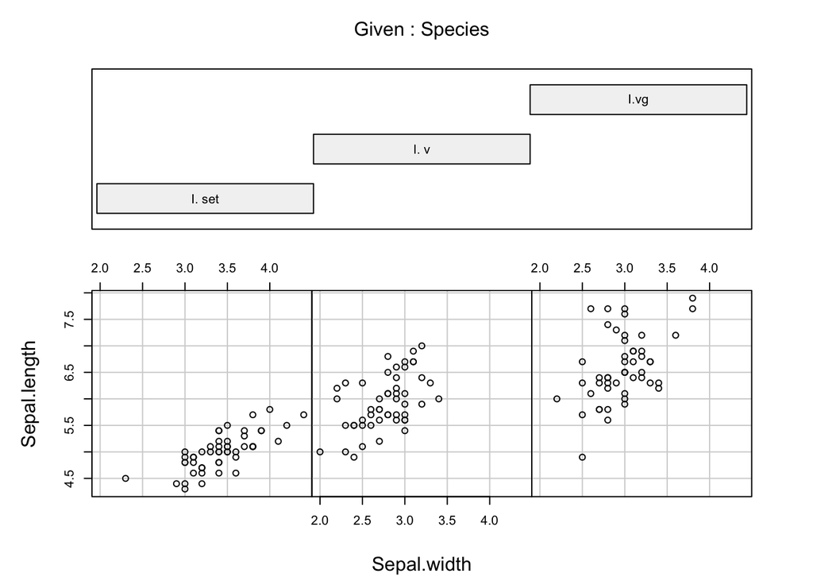

```r
coplot(Sepal.length~Sepal.width|Species,data=iris.data,rows=1)
```

Here we see that Sepal.length and Sepal.width are pretty strongly correlated in each of the species looked at here. Because of this, we should most likely include an interaction term in our model.  
We can also look at the same thing but include a linear model (regression line) we do this by installing and running the Lattace package.

```r
#xyplot(Sepal.length~Sepal.width|Species,data=iris.data,type=c("p","r"))
```

Did you get an error there? That error means that the package has not been loaded. Lets figure out which one now.  
Type in:

```r
?xyplot
```

```
## No documentation for 'xyplot' in specified packages and libraries:
## you could try '??xyplot'
```

```r
??xylot
```

So the package we want to load is “lattice.” Go up to Tools-Install Packages and load it now. Now try that again:

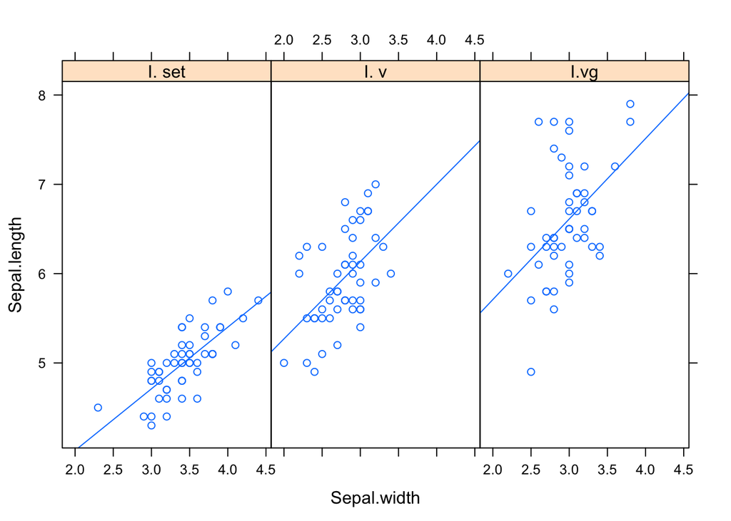

```r
library(lattice)
xyplot(Sepal.length~Sepal.width|Species,data=iris.data,type=c("p","r"))
```

These OLS slopes all resemble each other, which is good, and means that each species has a similar relationship between the two traits. If this changed we would have to use a more complicated mixed model.

#### 8. Are observations of the response variable independent?

This gets into the regression models class.

### ACTIVITY 2.

Make a box plot with sepal length by species. What is the value of the outliers? Figure this out using R. Hint: check out the help file.

### 2. Simple univariate statistics

#### T-tests.

T-tests are used to test a number of different kinds of hypotheses, such as testing whether the true population mean (parameter) is equal to a specified value given a sample distribution. Note that here we are focusing on all values contained in column 3 that are designated one species.

#### One sample t-test: Is the true population mean equal to a specified value (mu).

```r
t.test(iris.data[iris.data$Species=="I. set",3],mu=5)
```

```
##
##  One Sample t-test
##
## data:  iris.data[iris.data$Species == "I. set", 3]
## t = -29.324, df = 49, p-value < 2.2e-16
## alternative hypothesis: true mean is not equal to 5
## 95 percent confidence interval:
##  3.320271 3.535729
## sample estimates:
## mean of x
##     3.428
```

#### Two-sample t-test.

Aare the population means of two populations equal given the samples?

```r
t.test(iris.data[iris.data$Species=="I. v",3],iris.data[iris.data$Species=="I. set",3])
```

```
##
##  Welch Two Sample t-test
##
## data:  iris.data[iris.data$Species == "I. v", 3] and iris.data[iris.data$Species == "I. set", 3]
## t = -9.455, df = 94.698, p-value = 2.484e-15
## alternative hypothesis: true difference in means is not equal to 0
## 95 percent confidence interval:
##  -0.7961652 -0.5198348
## sample estimates:
## mean of x mean of y
##     2.770     3.428
```

#### Paired t-test.

Do two sets of matched data or repeatedly taken data have the same mean?

```r
t.test(iris.data[iris.data$Species=="I. v",3],iris.data[iris.data$Species=="I. set",3],paired=T)
```

```
##
##  Paired t-test
##
## data:  iris.data[iris.data$Species == "I. v", 3] and iris.data[iris.data$Species == "I. set", 3]
## t = -8.8506, df = 49, p-value = 9.857e-12
## alternative hypothesis: true difference in means is not equal to 0
## 95 percent confidence interval:
##  -0.807403 -0.508597
## sample estimates:
## mean of the differences
##                  -0.658
```

You can also do this indexing the data by the column names as follows (but I’ll keep using the column number (3) for brevity).

```r
t.test(iris.data[iris.data$Species=="I. v","Sepal.width"],iris.data[iris.data$Species=="I. set","Sepal.width"],paired=T)
```

```
##
##  Paired t-test
##
## data:  iris.data[iris.data$Species == "I. v", "Sepal.width"] and iris.data[iris.data$Species == "I. set", "Sepal.width"]
## t = -8.8506, df = 49, p-value = 9.857e-12
## alternative hypothesis: true difference in means is not equal to 0
## 95 percent confidence interval:
##  -0.807403 -0.508597
## sample estimates:
## mean of the differences
##                  -0.658
```

#### Mann-Whitney U.

Mann-Whitney U is a non-parametric test used for if one of two samples generally has larger values than the other. This test assumes independence between the samples. Mann-Whitney U: Does one sample have significantly larger values than the other?

```r
wilcox.test(iris.data[iris.data$Species=="I. set",3],iris.data[iris.data$Species=="I. v",3])
```

```
##
##  Wilcoxon rank sum test with continuity correction
##
## data:  iris.data[iris.data$Species == "I. set", 3] and iris.data[iris.data$Species == "I. v", 3]
## W = 2312, p-value = 2.143e-13
## alternative hypothesis: true location shift is not equal to 0
```

#### Wilcoxson Signed-rank test.

Wilcoxson signed rank test is a non-parametric test used for testing if the population means differ based on non-independent samples (related, matched, repeated). Wilcoxson signed rank test: Do population means differ given non-independent samples?

```r
wilcox.test(iris.data[iris.data$Species=="I. set",3],iris.data[iris.data$Species=="I. v",3],paired=T)
```

```
##
##  Wilcoxon signed rank test with continuity correction
##
## data:  iris.data[iris.data$Species == "I. set", 3] and iris.data[iris.data$Species == "I. v", 3]
## V = 1047, p-value = 3.19e-08
## alternative hypothesis: true location shift is not equal to 0
```

#### Kolmogorov-Smirnov.

The KS test is a non-parametric test that compares two sample distributions or one sample to a reference distribution, and is sensitive to both location and shape of probability distribution. The KS test: are the sample distributions significantly different from each other?

```r
ks.test(iris.data[iris.data$Species=="I. set",4],iris.data[iris.data$Species=="I. v",4])
```

```
##
##  Two-sample Kolmogorov-Smirnov test
##
## data:  iris.data[iris.data$Species == "I. set", 4] and iris.data[iris.data$Species == "I. v", 4]
## D = 1, p-value < 2.2e-16
## alternative hypothesis: two-sided
```

#### ANOVA.

ANOVA is a parametric test commonly used for testing if the means of three or more samples with different treatments (categorical classification variables) are equal. It assumes independent samples. In the iris data set, we will use Species as our classification variable, and we will test if one of the species means for Sepal.length is significantly different from the others.

Hypotheses: H0: u1=u2=u3 H1: At least one of the means is not equal.

#### One-way ANOVA.

One categorical variable and one continuous dependent variable.

```r
aov(Sepal.length~Species ,data=iris.data)
```

```
## Call:
##    aov(formula = Sepal.length ~ Species, data = iris.data)
##
## Terms:
##                  Species Residuals
## Sum of Squares  63.21213  38.95620
## Deg. of Freedom        2       147
##
## Residual standard error: 0.5147894
## Estimated effects may be unbalanced
```

This result gives you the among and within sums of squares, which can be useful, but to get the main results:

```r
summary(aov(Sepal.length~Species ,data=iris.data))
```

```
##              Df Sum Sq Mean Sq F value Pr(>F)
## Species       2  63.21  31.606   119.3 <2e-16 ***
## Residuals   147  38.96   0.265
## ---
## Signif. codes:  0 '***' 0.001 '**' 0.01 '*' 0.05 '.' 0.1 ' ' 1
```

Looking at the p value we see that there is an effect of the Species categorical variable on the means - in other words, at least one Sepal.length mean is different between the three species.

#### Two-way ANOVAs.

Use more than one categorical variable and can be added to the equation with the + symbol.

#### Kruskal-Wallace.

The KW test is an extension of the Mann-Whitney U test for comparing three or more samples - a non-parametric test for determining whether independent samples origi- nate from the same distribution. Equivalent to a parametric one-way ANOVA. The KW test: Do three or more samples come from the same distribution? The code below breaks the Sepal.width column down to compare whether Sepal.width differs by species.

```r
kruskal.test(Sepal.width~Species ,data=iris.data)
```

```
##
##  Kruskal-Wallis rank sum test
##
## data:  Sepal.width by Species
## Kruskal-Wallis chi-squared = 63.571, df = 2, p-value = 1.569e-14
```

### ACTIVITY 3.

Perform a Mann-Whitney U between the second and third species in the data set and the variable Petal.width.